# (20-1) Regression Analysis - COVID-19

고영현 (2014-19984)

2020-06-13

### 1. Using the confirmed data of Brazil, analyze the below.

#### (1-1) 해당 국가에 대하여 최근 5/31일까지의 새로운 자료를 다운 받을 것.

```r
# 필요한 col뽑기
corona_raw <- COVID_19 %>%
  select(1, 3:5, 7) %>%
  rename(Case_Type = 癤풠ase_Type) %>%
  group_by(Country_Region, Date, Case_Type) %>%
  summarise(Cases = sum(Cases)) %>%
  ungroup()

# 신규확진자 구하기
corona <- corona_raw %>%
  mutate(Date = as.Date(corona_raw$Date, '%m/%d/%Y')) %>%
  filter(Case_Type == "Confirmed") %>%
  arrange(Country_Region, Date) %>%
  mutate(Days_after_First_Case = rep(0:133, 187),
         Difference = Cases - lag(Cases, n = 1, default = 0))

# difference 끝지점 예외 처리
for(i in 0:186){
  corona$Difference[134*i + 1] = corona$Cases[134*i + 1]
}

Brazil <- corona %>%
  filter(Country_Region == "Brazil") %>%
  slice(1:131)

# 확진자가 출현했을 시점부터
Brazil <- Brazil[Brazil$Cases!=0,]


# 2월 26일부터 4월 19일까지의 데이터를 training set
# 4월 20일부터 5월 31일까지의 데이터를 validation set
Brazil_train <- Brazil[1:54,]; Brazil_valid <- Brazil[55:96,]
```

#### (1-2) 1차 분석 날짜인 4/19일까지 자료를 이용하여 예측한 Logistic, Bertalanffy, Gompertz model의 모형 결과로부터 5/31일까지의 일별 예측값을 구할 것

```r
X <- Brazil_train$Days_after_First_Case
Y <- Brazil_train$Cases


## 그리드 탐색
grid_Brazil <- data.frame(a = c(max(Y) - 20000, max(Y) + 20000), b = c(-100, 100), c = c(-100, 100))


## Logistic  model
eq_log <- Y ~ a/(1 + exp(b + c*X))

# 초기값 생성
# fit_log_B <- nls2(eq_log, start = grid_Brazil, algorithm = "plinear-random", control = nls.control(maxiter = 3000))
# initial_log_B <- coef(fit_log_B)
initial_log_B <- c(4.610237e+04,  7.795043e+00, -9.751111e-02)

# 초기값을 바탕으로 적합
fit_log_B <- nls(eq_log, start = list(a = initial_log_B[1],
                                     b = initial_log_B[2],
                                     c = initial_log_B[3]))
summary(fit_log_B)
```

```
##
## Formula: Y ~ a/(1 + exp(b + c * X))
##
## Parameters:
##     Estimate Std. Error t value Pr(>|t|)
## a  6.341e+04  3.689e+03   17.19   <2e-16 ***
## b  1.199e+01  2.596e-01   46.18   <2e-16 ***
## c -1.407e-01  4.281e-03  -32.87   <2e-16 ***
## ---
## Signif. codes:  0 '***' 0.001 '**' 0.01 '*' 0.05 '.' 0.1 ' ' 1
##
## Residual standard error: 547.9 on 51 degrees of freedom
##
## Number of iterations to convergence: 7
## Achieved convergence tolerance: 6.347e-06
```

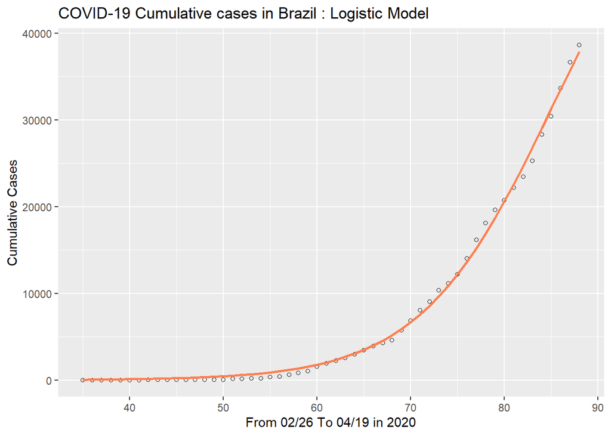

```r
ggplot() +
  geom_point(aes(X, Y), shape = 1) +
  geom_line(aes(X, coef(fit_log_B)[1] / (1 + exp(coef(fit_log_B)[2] + coef(fit_log_B)[3] * X))),
            color = "coral", lwd = 1) +
  labs(title = "COVID-19 Cumulative cases in Brazil : Logistic Model",
       x = "From 02/26 To 04/19 in 2020", y = "Cumulative Cases")
```

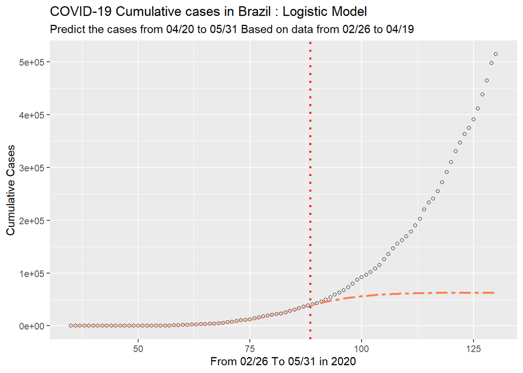

```r
## 일별 예측값
X_pred <- Brazil_valid$Days_after_First_Case
Y_pred <- Brazil_valid$Cases

ggplot() +
  geom_point(aes(X, Y), shape = 1) +
  geom_line(aes(X, coef(fit_log_B)[1] / (1 + exp(coef(fit_log_B)[2] + coef(fit_log_B)[3] * X))),
            color = "coral", size = 1.5, alpha = 0.3) +
  labs(title = "COVID-19 Cumulative cases in Brazil : Logistic Model",
       subtitle = "Predict the cases from 04/20 to 05/31 Based on data from 02/26 to 04/19",
       x = "From 02/26 To 05/31 in 2020", y = "Cumulative Cases") +

  # 4월 20일부터 5월 31일까지 예측
  geom_point(aes(X_pred, Y_pred), shape = 1) +
  geom_line(aes(X_pred, coef(fit_log_B)[1] / (1 + exp(coef(fit_log_B)[2] + coef(fit_log_B)[3] * X_pred))),
             col = "coral", size = 1, linetype = 6) +
  geom_vline(xintercept = 88.5, col = "red", lwd = 1, linetype = 3)
```

```r
## Bertalanffy model
eq_Ber <- Y ~ a * ((1 - exp((-b) * X))^c)

# 초기값 생성
# fit_Ber_B = nls2(eq_Ber, start = grid_Brazil, algorithm = "plinear-random", control = nls.control(maxiter = 5000))
# initial_Ber_B <- coef(fit_Ber_B)
initial_Ber_B <- c(2.699297e+05, 3.379691e-02, 3.717493e+01)

# 초기값을 바탕으로 적합
fit_Ber_B <- nls(eq_Ber, start = list(a = initial_Ber_B[1],
                                     b = initial_Ber_B[2],
                                     c = initial_Ber_B[3]))

summary(fit_Ber_B)
```

```
##
## Formula: Y ~ a * ((1 - exp((-b) * X))^c)
##
## Parameters:
##    Estimate Std. Error t value Pr(>|t|)
## a 2.699e+05  5.135e+04   5.257 2.91e-06 ***
## b 3.380e-02  2.675e-03  12.635  < 2e-16 ***
## c 3.717e+01  5.465e+00   6.802 1.12e-08 ***
## ---
## Signif. codes:  0 '***' 0.001 '**' 0.01 '*' 0.05 '.' 0.1 ' ' 1
##
## Residual standard error: 393.8 on 51 degrees of freedom
##
## Number of iterations to convergence: 1
## Achieved convergence tolerance: 7.65e-07
```

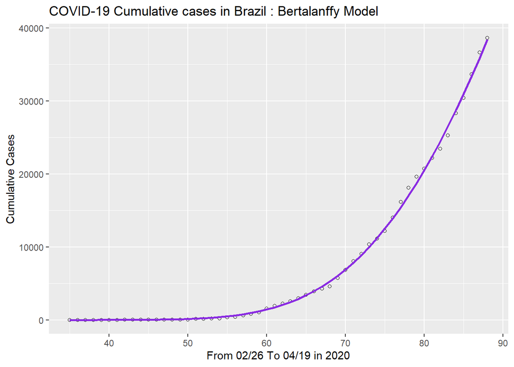

```r
# 시각화
ggplot() +
  geom_point(aes(X, Y), shape = 1) +
  geom_line(aes(X, coef(fit_Ber_B)[1] * ((1 - exp(-coef(fit_Ber_B)[2] * X ))^coef(fit_Ber_B)[3])),
            color = "blueviolet", lwd = 1) +
  labs(title = "COVID-19 Cumulative cases in Brazil : Bertalanffy Model",
       x = "From 02/26 To 04/19 in 2020", y = "Cumulative Cases")
```

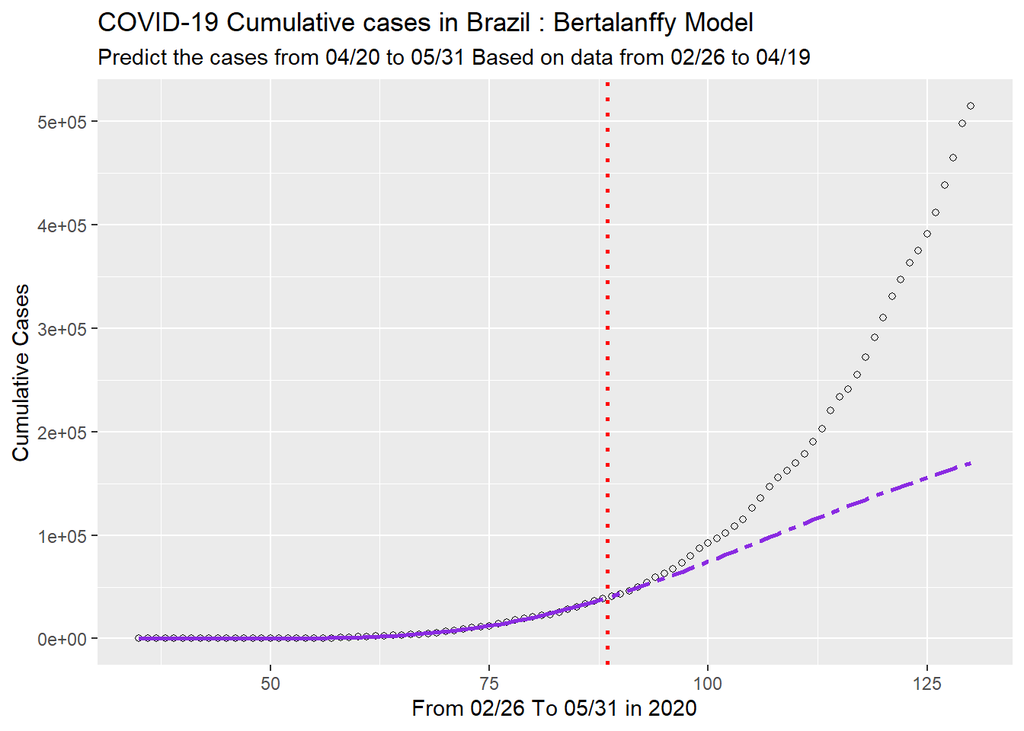

```r
## 일별 예측값
X_pred <- Brazil_valid$Days_after_First_Case
Y_pred <- Brazil_valid$Cases

ggplot() +
  geom_point(aes(X, Y), shape = 1) +
  geom_line(aes(X, coef(fit_Ber_B)[1] * ((1 - exp(-coef(fit_Ber_B)[2] * X ))^coef(fit_Ber_B)[3])),
            color = "blueviolet", lwd = 1) +
  labs(title = "COVID-19 Cumulative cases in Brazil : Bertalanffy Model",
       subtitle = "Predict the cases from 04/20 to 05/31 Based on data from 02/26 to 04/19",
       x = "From 02/26 To 05/31 in 2020", y = "Cumulative Cases") +

  # 4월 20일부터 5월 31일까지 예측
  geom_point(aes(X_pred, Y_pred), shape = 1) +
  geom_line(aes(X_pred, coef(fit_Ber_B)[1] * ((1 - exp(-coef(fit_Ber_B)[2] * X_pred))^coef(fit_Ber_B)[3])),
             col = "blueviolet", size = 1, linetype = 6) +
  geom_vline(xintercept = 88.5, col = "red", lwd = 1, linetype = 3)
```

```r
## Gompertz model
eq_Gom <- Y ~ a * exp(-b * exp(-c * X))

# 초기값 생성
# fit_Gom_B = nls2(eq_Gom, start = grid_Brazil, algorithm = "plinear-random", control = nls.control(maxiter = 5000))
# initial_Gom_B <- coef(fit_Gom_B)
initial_Gom_B <- c(5.581085e+04, 3.473065e+01, 2.421904e-02)

# 초기값을 바탕으로 적합
fit_Gom_B <- nls(eq_Gom, start = list(a = initial_Gom_B[1],
                                     b = initial_Gom_B[2],
                                     c = initial_Gom_B[3]))
summary(fit_Gom_B)
```

```
##
## Formula: Y ~ a * exp(-b * exp(-c * X))
##
## Parameters:
##    Estimate Std. Error t value Pr(>|t|)
## a 2.392e+05  3.808e+04   6.280 7.46e-08 ***
## b 4.648e+01  5.467e+00   8.503 2.40e-11 ***
## c 3.676e-02  2.289e-03  16.060  < 2e-16 ***
## ---
## Signif. codes:  0 '***' 0.001 '**' 0.01 '*' 0.05 '.' 0.1 ' ' 1
##
## Residual standard error: 396.4 on 51 degrees of freedom
##
## Number of iterations to convergence: 9
## Achieved convergence tolerance: 2.834e-06
```

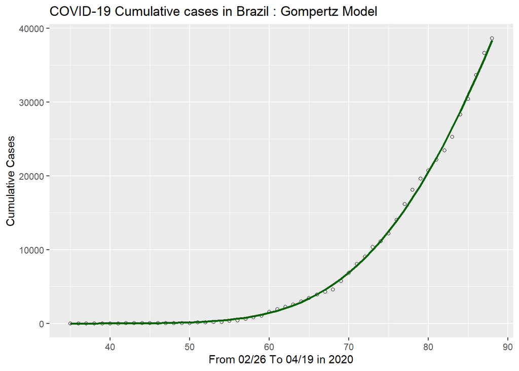

```r
# 시각화
ggplot() +
  geom_point(aes(X, Y), shape = 1) +
  geom_line(aes(X, coef(fit_Gom_B)[1] * (exp(-coef(fit_Gom_B)[2] * exp(-coef(fit_Gom_B)[3] * X )))),
            color = "darkgreen", size = 1) +
  labs(title = "COVID-19 Cumulative cases in Brazil : Gompertz Model",
       x = "From 02/26 To 04/19 in 2020", y = "Cumulative Cases")
```

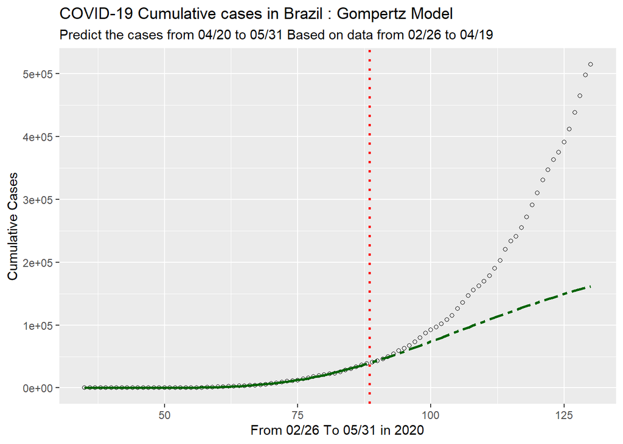

```r
## 일별 예측값
X_pred <- Brazil_valid$Days_after_First_Case
Y_pred <- Brazil_valid$Cases

ggplot() +
  geom_point(aes(X, Y), shape = 1) +
  geom_line(aes(X, coef(fit_Gom_B)[1] * (exp(-coef(fit_Gom_B)[2] * exp(-coef(fit_Gom_B)[3] * X )))),
            color = "darkgreen", lwd = 1) +
  labs(title = "COVID-19 Cumulative cases in Brazil : Gompertz Model",
       subtitle = "Predict the cases from 04/20 to 05/31 Based on data from 02/26 to 04/19",
       x = "From 02/26 To 05/31 in 2020", y = "Cumulative Cases") +

  # 4월 20일부터 5월 31일까지 예측
  geom_point(aes(X_pred, Y_pred), shape = 1) +
  geom_line(aes(X_pred, coef(fit_Gom_B)[1] * (exp(-coef(fit_Gom_B)[2] * exp(-coef(fit_Gom_B)[3] * X_pred)))),
             col = "darkgreen", size = 1, linetype = 6) +
  geom_vline(xintercept = 88.5, col = "red", lwd = 1, linetype = 3)
```

```r
X_pred <- Brazil_valid$Days_after_First_Case
Y_pred <- Brazil_valid$Cases

Brazil_pred <- Brazil_valid %>%
  mutate(Logistic_pred = predict(fit_log_B, data.frame(X = X_pred)),
         Ber_pred = predict(fit_Ber_B, data.frame(X = X_pred)),
         Gom_pred = predict(fit_Gom_B, data.frame(X = X_pred)))

Brazil_pred %>%
  select(2, 4, 7:9)
```

```
## # A tibble: 42 x 5
##    Date       Cases Logistic_pred Ber_pred Gom_pred
##    <date>     <int>         <dbl>    <dbl>    <dbl>
##  1 2020-04-20 40743        40005.   41060.   41015.
##  2 2020-04-21 43079        42041.   43780.   43710.
##  3 2020-04-22 45757        43987.   46576.   46475.
##  4 2020-04-23 50036        45829.   49443.   49306.
##  5 2020-04-24 54043        47560.   52378.   52198.
##  6 2020-04-25 59324        49173.   55377.   55147.
##  7 2020-04-26 63100        50666.   58434.   58146.
##  8 2020-04-27 67446        52038.   61546.   61191.
##  9 2020-04-28 73235        53292.   64707.   64277.
## 10 2020-04-29 79685        54432.   67913.   67399.
## # ... with 32 more rows
```

#### (1-3) 모형의 예측값과 실제 관측값을 하나의 plot에 나타낼 것. X축은 첫 케이스가 발생한 날부터 흐른 날짜를 나타내고, Y축은 실제 관찰된 값을 점으로 표시하고 각 모형의 예측값은 선으로 나타낼 것.

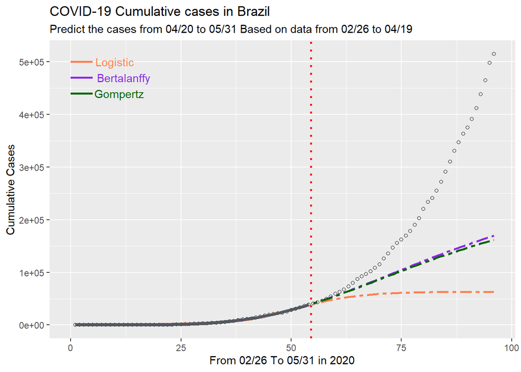

```r
X <- Brazil_train$Days_after_First_Case
Y <- Brazil_train$Cases

ggplot() +
  geom_point(aes(X-34, Y), shape = 1) +
  geom_line(aes(X-34, coef(fit_log_B)[1] / (1 + exp(coef(fit_log_B)[2] + coef(fit_log_B)[3] * X))),
            color = "coral", size = 1.5, alpha = 0.7) +
  geom_line(aes(X-34, coef(fit_Ber_B)[1] * ((1 - exp(-coef(fit_Ber_B)[2] * X))^coef(fit_Ber_B)[3])),
            color = "blueviolet", size = 1.5, alpha = 0.7) +
  geom_line(aes(X-34, coef(fit_Gom_B)[1] * (exp(-coef(fit_Gom_B)[2] * exp(-coef(fit_Gom_B)[3] * X)))),
            color = "darkgreen", size = 1.5, alpha = 0.5) +
  labs(title = "COVID-19 Cumulative cases in Brazil",
       subtitle = "Predict the cases from 04/20 to 05/31 Based on data from 02/26 to 04/19",
       x = "From 02/26 To 05/31 in 2020", y = "Cumulative Cases") +

  # 4월 20일부터 5월 31일까지 예측
  geom_point(aes(X_pred-34, Y_pred), shape = 1) +
  geom_vline(xintercept = 88.5-34, col = "red", lwd = 1, linetype = 3) +

  # Logistic model
  geom_line(aes(X_pred-34, coef(fit_log_B)[1] / (1 + exp(coef(fit_log_B)[2] + coef(fit_log_B)[3] * X_pred))),
             col = "coral", size = 1, linetype = 6) +
  geom_line(aes(x = 0:5, y = 500000), col = "coral", size = 1) +
  geom_text(aes(x = 10, y = 500000, label = "Logistic"), color = "coral") +

  # Bertalanffy model
  geom_line(aes(X_pred-34, coef(fit_Ber_B)[1] * ((1 - exp(-coef(fit_Ber_B)[2] * X_pred))^coef(fit_Ber_B)[3])),
             col = "blueviolet", size = 1, linetype = 6) +
  geom_line(aes(x = 0:5, y = 470000), col = "blueviolet", size = 1) +
  geom_text(aes(x = 12, y = 470000, label = "Bertalanffy"), color = "blueviolet") +

  # Gompertz model
  geom_line(aes(X_pred-34, coef(fit_Gom_B)[1] * (exp(-coef(fit_Gom_B)[2] * exp(-coef(fit_Gom_B)[3] * X_pred)))),
             col = "darkgreen", size = 1, linetype = 6) +
  geom_line(aes(x = 0:5, y = 440000), col = "darkgreen", size = 1) +
  geom_text(aes(x = 11, y = 440000, label = "Gompertz"), color = "darkgreen")
```

#### (1-4) 4/20 – 5/31 까지의 일별 관찰값과 예측값을 사용하여 MSE 를 구할 것

```r
## Logistic Model MSE
SSE_log <- sum((Brazil_pred$Cases - Brazil_pred$Logistic_pred)^2)
SST_log <- sum((Brazil_pred$Cases - mean(Brazil_train$Cases))^2)
MSE_log <- SSE_log / length(Brazil_pred$Cases)


## Bertalanffy Model MSE
SSE_Ber <- sum((Brazil_pred$Cases - Brazil_pred$Ber_pred)^2)
SST_Ber <- sum((Brazil_pred$Cases - mean(Brazil_train$Cases))^2)
MSE_Ber <- SSE_Ber / length(Brazil_pred$Cases)


## Gompertz Model MSE
SSE_Gom <- sum((Brazil_pred$Cases - Brazil_pred$Gom_pred)^2)
SST_Gom <- sum((Brazil_pred$Cases - mean(Brazil_train$Cases))^2)
MSE_Gom <- SSE_Gom / length(Brazil_pred$Cases)


cat("(Logistic) MSE : ", MSE_log, "\n")
```

```
## (Logistic) MSE :  39437115377
```

```r
cat("(Bertalanffy) MSE: ", MSE_Ber, "\n")
```

```
## (Bertalanffy) MSE:  20014585604
```

```r
cat("(Gompertz) MSE : ", MSE_Gom)
```

```
## (Gompertz) MSE :  21110099077
```

Brazil_pred data set를 바탕으로 하기 때문에 MSPE(Mean Sqaured Prediction Error)를 계산하였다.

#### (1-5) MSE를 기반으로 세 모형 중에서 어떤 모형이 제일 자료를 잘 적합하는 지 판단하시오.

```r
R_squared_log <- 1 - SSE_log/SST_log
R_squared_Ber <- 1 - SSE_Ber/SST_Ber
R_squared_Gom <- 1 - SSE_Gom/SST_Gom

cat("(Logistic) R_squared : ", R_squared_log, "\n")
```

```
## (Logistic) R_squared :  0.3204375
```

```r
cat("(Bertalanffy) R_squared : ", R_squared_Ber, "\n")
```

```
## (Bertalanffy) R_squared :  0.6551177
```

```r
cat("(Gompertz) R_squared : ", R_squared_Gom)
```

```
## (Gompertz) R_squared :  0.6362403
```

(4)에서 도출한 검정 MSE를 바탕으로 결정계수 $R^2$를 비교한 결과, (3)의 그래프 모양대로 Bertalanffy > Gompertz > Logistic model 순으로 설명력이 높은 것을 알 수 있다.

### 2. 첨부한 엑셀 파일에 본인이 담당했던 국가 이외에 2개의 새로운 국가가 배정되어 있음. 이 3가지 국가 자료에 대해 최근 5/31일까지의 자료를 다운받아

#### (2-1) Logistic, Bertalanffy, Gompertz model의 모형을 새로 적합할 것

#### 헝가리 데이터

```r
## 헝가리 데이터

Hungary <- corona %>%
  filter(Country_Region == "Hungary") %>%
  slice(1:131)

Hungary <- Hungary[Hungary$Cases!=0,]
Hungary_train <- Hungary[1:47,]; Hungary_valid <- Hungary[48:89,]

X <- Hungary$Days_after_First_Case
Y <- Hungary$Cases


## 그리드 탐색
grid_Hungary <- data.frame(a = c(min(Y), max(Y) + 5000), b = c(-30, 30), c = c(-30, 30))
```

```r
## Logistic  model
eq_log <- Y ~ a/(1 + exp(b + c*X))

## 초기값 생성
#fit_log_H <- nls2(eq_log, start = grid_Hungary, algorithm = "plinear-random", control = nls.control(maxiter = 1000))
#initial_log_H <- coef(fit_log_H)
initial_log_H <- c(795.4851914, 7.1441869, -0.1050411 )

# 초기값을 바탕으로 적합
fit_log_H <- nls(eq_log, start = list(a = initial_log_H[1],
                                     b = initial_log_H[2],
                                     c = initial_log_H[3]))
summary(fit_log_H)
```

```
##
## Formula: Y ~ a/(1 + exp(b + c * X))
##
## Parameters:
##     Estimate Std. Error t value Pr(>|t|)
## a  3.787e+03  2.405e+01  157.48   <2e-16 ***
## b  8.669e+00  1.486e-01   58.35   <2e-16 ***
## c -9.833e-02  1.814e-03  -54.19   <2e-16 ***
## ---
## Signif. codes:  0 '***' 0.001 '**' 0.01 '*' 0.05 '.' 0.1 ' ' 1
##
## Residual standard error: 74.25 on 86 degrees of freedom
##
## Number of iterations to convergence: 7
## Achieved convergence tolerance: 1.293e-06
```

```r
## Bertalanffy model
eq_Ber <- Y ~ a * ((1 - exp((-b) * X))^c)

## 초기값 생성
#fit_Ber_H = nls2(eq_Ber, start = grid_Hungary, algorithm = "plinear-random", control = nls.control(maxiter = 3000))
#initial_Ber_H <- coef(fit_Ber_H)
initial_Ber_H <- c(3.122438e+03, 5.375042e-02, 2.899045e+01)

# 초기값을 바탕으로 적합
fit_Ber_H <- nls(eq_Ber, start = list(a = initial_Ber_H[1],
                                     b = initial_Ber_H[2],
                                     c = initial_Ber_H[3]))

summary(fit_Ber_H)
```

```
##
## Formula: Y ~ a * ((1 - exp((-b) * X))^c)
##
## Parameters:
##    Estimate Std. Error t value Pr(>|t|)
## a 4.136e+03  2.319e+01  178.34   <2e-16 ***
## b 5.621e-02  7.486e-04   75.09   <2e-16 ***
## c 1.061e+02  6.096e+00   17.40   <2e-16 ***
## ---
## Signif. codes:  0 '***' 0.001 '**' 0.01 '*' 0.05 '.' 0.1 ' ' 1
##
## Residual standard error: 40.98 on 86 degrees of freedom
##
## Number of iterations to convergence: 11
## Achieved convergence tolerance: 1.723e-06
```

```r
## Gompertz model
eq_Gom <- Y ~ a * exp(-b * exp(-c * X))

## 초기값 생성
#fit_Gom_H = nls2(eq_Gom, start = grid_Hungary, algorithm = "plinear-random", control = nls.control(maxiter = 5000))
#initial_Gom_H <- coef(fit_Gom_H)
initial_Gom_H <- c(5.880673e+03, 4.614169e+00, 1.553079e-02)

# 초기값을 바탕으로 적합
fit_Gom_H <- nls(eq_Gom, start = list(a = initial_Gom_H[1],
                                     b = initial_Gom_H[2],
                                     c = initial_Gom_H[3]))
summary(fit_Gom_H)
```

```
##
## Formula: Y ~ a * exp(-b * exp(-c * X))
##
## Parameters:
##    Estimate Std. Error t value Pr(>|t|)
## a 4.131e+03  2.261e+01  182.69   <2e-16 ***
## b 1.097e+02  6.060e+00   18.10   <2e-16 ***
## c 5.656e-02  7.240e-04   78.12   <2e-16 ***
## ---
## Signif. codes:  0 '***' 0.001 '**' 0.01 '*' 0.05 '.' 0.1 ' ' 1
##
## Residual standard error: 40.7 on 86 degrees of freedom
##
## Number of iterations to convergence: 11
## Achieved convergence tolerance: 7.471e-07
```

#### 파라과이 데이터

```r
## 파라과이 데이터
Paraguay <- corona %>%
  filter(Country_Region == "Paraguay") %>%
  slice(1:131)

Paraguay <- Paraguay[Paraguay$Cases!=0,]
Paraguay_train <- Paraguay[1:43,]; Paraguay_valid <- Paraguay[44:85,]

X <- Paraguay$Days_after_First_Case
Y <- Paraguay$Cases

## 그리드 탐색
grid_Paraguay <- data.frame(a = c(min(Y), max(Y) + 5000), b = c(-30, 30), c = c(-30, 30))
```

```r
## Logistic  model
eq_log <- Y ~ a/(1 + exp(b + c*X))

## 초기값 생성
#fit_log_P <- nls2(eq_log, start = grid_Paraguay, algorithm = "plinear-random", control = nls.control(maxiter = 2000))
#initial_log_P <- coef(fit_log_P)
initial_log_P <- c(4047.47778198, 12.78304533, -0.08859789)

# 초기값을 바탕으로 적합
fit_log_P <- nls(eq_log, start = list(a = initial_log_P[1],
                                     b = initial_log_P[2],
                                     c = initial_log_P[3]))
summary(fit_log_P)
```

```
##
## Formula: Y ~ a/(1 + exp(b + c * X))
##
## Parameters:
##     Estimate Std. Error t value Pr(>|t|)
## a 1104.02421   43.18367   25.57   <2e-16 ***
## b    9.28118    0.41838   22.18   <2e-16 ***
## c   -0.08678    0.00468  -18.54   <2e-16 ***
## ---
## Signif. codes:  0 '***' 0.001 '**' 0.01 '*' 0.05 '.' 0.1 ' ' 1
##
## Residual standard error: 44.11 on 82 degrees of freedom
##
## Number of iterations to convergence: 29
## Achieved convergence tolerance: 4.143e-06
```

```r
## Bertalanffy model
eq_Ber <- Y ~ a * ((1 - exp((-b) * X))^c)

## 초기값 생성
#fit_Ber_P = nls2(eq_Ber, start = grid_Paraguay, algorithm = "plinear-random", control = nls.control(maxiter = 3000))
#initial_Ber_P <- coef(fit_Ber_P)
initial_Ber_P <- c(2.965750e+03, 2.059801e-02, 7.276436e+00)

# 초기값을 바탕으로 적합
fit_Ber_P <- nls(eq_Ber, start = list(a = initial_Ber_P[1],
                                     b = initial_Ber_P[2],
                                     c = initial_Ber_P[3]))

summary(fit_Ber_P)
```

```
##
## Formula: Y ~ a * ((1 - exp((-b) * X))^c)
##
## Parameters:
##    Estimate Std. Error t value Pr(>|t|)
## a 1.845e+03  2.857e+02   6.456 7.13e-09 ***
## b 3.069e-02  4.298e-03   7.142 3.40e-10 ***
## c 3.205e+01  1.077e+01   2.977  0.00383 **
## ---
## Signif. codes:  0 '***' 0.001 '**' 0.01 '*' 0.05 '.' 0.1 ' ' 1
##
## Residual standard error: 52.62 on 82 degrees of freedom
##
## Number of iterations to convergence: 17
## Achieved convergence tolerance: 3.823e-06
```

```r
## Gompertz model
eq_Gom <- Y ~ a * exp(-b * exp(-c * X))

## 초기값 생성
#fit_Gom_P = nls2(eq_Gom, start = grid_Paraguay, algorithm = "plinear-random", control = nls.control(maxiter = 5000))
#initial_Gom_P <- coef(fit_Gom_P)
initial_Gom_P <- c(2.014590e+03, 1.280609e+01, 3.247128e-02)

# 초기값을 바탕으로 적합
fit_Gom_P <- nls(eq_Gom, start = list(a = initial_Gom_P[1],
                                     b = initial_Gom_P[2],
                                     c = initial_Gom_P[3]))

summary(fit_Gom_P)
```

```
##
## Formula: Y ~ a * exp(-b * exp(-c * X))
##
## Parameters:
##    Estimate Std. Error t value Pr(>|t|)
## a 1.821e+03  2.563e+02   7.103 4.04e-10 ***
## b 3.593e+01  1.019e+01   3.527 0.000691 ***
## c 3.168e-02  3.790e-03   8.358 1.36e-12 ***
## ---
## Signif. codes:  0 '***' 0.001 '**' 0.01 '*' 0.05 '.' 0.1 ' ' 1
##
## Residual standard error: 52.3 on 82 degrees of freedom
##
## Number of iterations to convergence: 24
## Achieved convergence tolerance: 2.978e-06
```

#### (2) 모형의 예측값과 실제 관측값을 하나의 plot에 나타낼 것. X축은 첫 케이스가 발생한 날부터 흐른 날짜를 나타내고, Y축은 실제 관찰된 값을 점으로 표시하고 각 모형의 예측값은 선으로 나타낼 것.

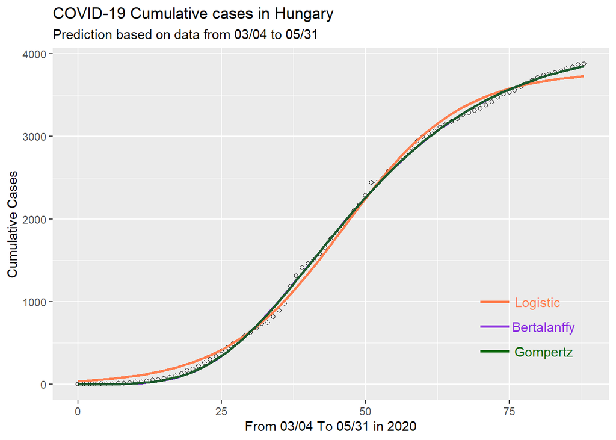

```r
## Hungary Data

X <- Hungary$Days_after_First_Case
Y <- Hungary$Cases


ggplot() +
  geom_point(aes(X-42, Y), shape = 1) +

  # Logistic model
  geom_line(aes(X-42, coef(fit_log_H)[1] / (1 + exp(coef(fit_log_H)[2] + coef(fit_log_H)[3] * X))),
            col = "coral", size = 1) +
  geom_line(aes(x = 70:75, y = 1000), col = "coral", size = 1) +
  geom_text(aes(x = 80, y = 1000, label = "Logistic"), color = "coral") +

  # Bertalanffy model
  geom_line(aes(X-42, coef(fit_Ber_H)[1] * ((1 - exp(-coef(fit_Ber_H)[2] * X))^coef(fit_Ber_H)[3])),
             col = "blueviolet", size = 1) +
  geom_line(aes(x = 70:75, y = 700), col = "blueviolet", size = 1) +
  geom_text(aes(x = 81, y = 700, label = "Bertalanffy"), color = "blueviolet") +

  # Gompertz model
  geom_line(aes(X-42, coef(fit_Gom_H)[1] * (exp(-coef(fit_Gom_H)[2] * exp(-coef(fit_Gom_H)[3] * X)))),
             col = "darkgreen", size = 1, alpha = 0.8) +
  geom_line(aes(x = 70:75, y = 400), col = "darkgreen", size = 1) +
  geom_text(aes(x = 81, y = 400, label = "Gompertz"), color = "darkgreen") +

  labs(title = "COVID-19 Cumulative cases in Hungary",
       subtitle = "Prediction based on data from 03/04 to 05/31",
       x = "From 03/04 To 05/31 in 2020", y = "Cumulative Cases")
```

세 그래프가 매우 비슷한 형태로 나타나며, 특히 Bertalanffy와 Gompertz model은 COVID-19 초기 단계부터 잠잠해지고 있는 5월 31일에 이르기까지 거의 겹친다는 것을 알 수 있다. Logistic model이 약간 다른 모양을 띤다.

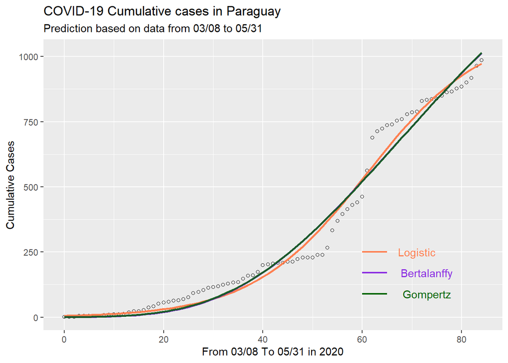

```r
## Paraguay Data

X <- Paraguay$Days_after_First_Case
Y <- Paraguay$Cases


ggplot() +
  geom_point(aes(X-46, Y), shape = 1) +

  # Logistic model
  geom_line(aes(X-46, coef(fit_log_P)[1] / (1 + exp(coef(fit_log_P)[2] + coef(fit_log_P)[3] * X))),
            col = "coral", size = 1) +
  geom_line(aes(x = 60:65, y = 250), col = "coral", size = 0.8) +
  geom_text(aes(x = 71, y = 250, label = "Logistic"), color = "coral") +

  # Bertalanffy model
  geom_line(aes(X-46, coef(fit_Ber_P)[1] * ((1 - exp(-coef(fit_Ber_P)[2] * X))^coef(fit_Ber_P)[3])),
             col = "blueviolet", size = 1) +
  geom_line(aes(x = 60:65, y = 170), col = "blueviolet", size = 0.8) +
  geom_text(aes(x = 73, y = 170, label = "Bertalanffy"), color = "blueviolet") +

  # Gompertz model
  geom_line(aes(X-46, coef(fit_Gom_P)[1] * (exp(-coef(fit_Gom_P)[2] * exp(-coef(fit_Gom_P)[3] * X)))),
             col = "darkgreen", size = 1, alpha = 0.8) +
  geom_line(aes(x = 60:65, y = 90), col = "darkgreen", size = 0.8) +
  geom_text(aes(x = 73, y = 90, label = "Gompertz"), color = "darkgreen") +

  labs(title = "COVID-19 Cumulative cases in Paraguay",
       subtitle = "Prediction based on data from 03/08 to 05/31",
       x = "From 03/08 To 05/31 in 2020", y = "Cumulative Cases")
```

Hungary 데이터와 마찬가지로 세 그래프가 매우 비슷한 형태로 나타나며, 특히 Bertalanffy와 Gompertz model은 COVID-19 확산 단계에서 약간의 차이가 날 뿐 시간이 지나가면서 거의 겹친다는 것을 알 수 있다.

### 3. 첨부한 논문에 있는 Poisson regression model을 참조하여 최근 5/31까지의 자료를 사용하여 모형을 적합하고 적합 결과를 그래프로 나타낼 것. 기존에 사용했던 3가지 모형과 비교해 볼 것.

#### (3-1) Poisson regression model in Hungary

```r
set.seed(1234)
fit_Poi_H <- glm(Difference ~ Days_after_First_Case, family = poisson, Hungary)
seg_Poi_H <- segmented(fit_Poi_H, seg.Z = ~ Days_after_First_Case, psi = 60)
summary(seg_Poi_H)
```

```
##
##  ***Regression Model with Segmented Relationship(s)***
##
## Call:
## segmented.glm(obj = fit_Poi_H, seg.Z = ~Days_after_First_Case,
##     psi = 60)
##
## Estimated Break-Point(s):
##                             Est. St.Err
## psi1.Days_after_First_Case   79  0.412
##
## Meaningful coefficients of the linear terms:
##                           Estimate Std. Error z value Pr(>|z|)
## (Intercept)              -3.061550   0.256097  -11.96   <2e-16 ***
## Days_after_First_Case     0.098328   0.003608   27.25   <2e-16 ***
## U1.Days_after_First_Case -0.130605   0.003867  -33.77       NA
## ---
## Signif. codes:  0 '***' 0.001 '**' 0.01 '*' 0.05 '.' 0.1 ' ' 1
## (Dispersion parameter for poisson family taken to be 1)
##
## Null     deviance: 2609.75  on 88  degrees of freedom
## Residual deviance:  759.16  on 85  degrees of freedom
## AIC: 1213.1
##
## Convergence attained in 12 iter. (rel. change 1.1619e-06)
```

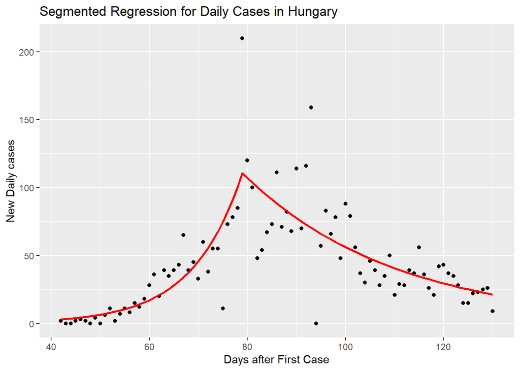

```r
Hungary <- Hungary %>% mutate(seg_fitted = fitted(seg_Poi_H))


# plot the fitted model
ggplot(Hungary) +
  geom_point(aes(Days_after_First_Case, Difference)) +
  geom_line(aes(Days_after_First_Case, seg_fitted), col = 2, size = 1) +
  labs(title = "Segmented Regression for Daily Cases in Hungary",
       x = "Days after First Case", y = "New Daily cases")
```

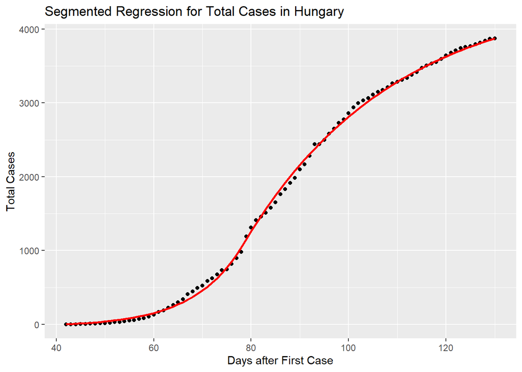

```r
# Plot the cumulative cases
ggplot(Hungary) +
  geom_point(aes(Days_after_First_Case, Cases)) +
  geom_line(aes(Days_after_First_Case, cumsum(seg_fitted)), col = 2, size = 1) +
  labs(title = "Segmented Regression for Total Cases in Hungary",
       x = "Days after First Case", y = "Total Cases")
```

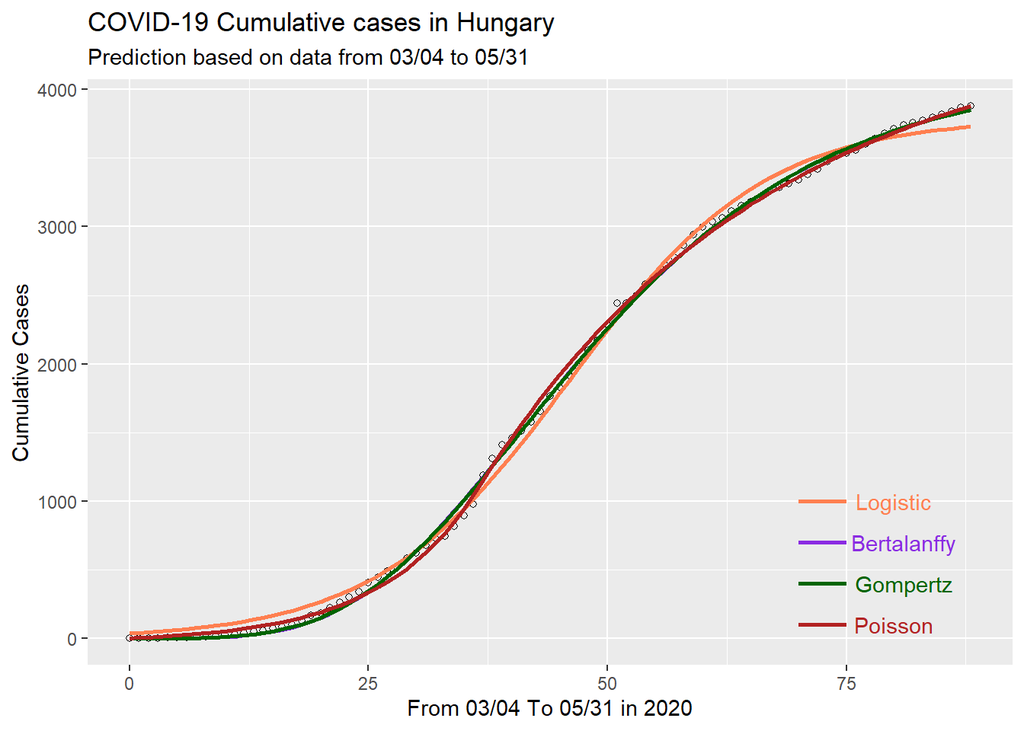

```r
## Plot
X <- Hungary$Days_after_First_Case
Y <- Hungary$Cases

Hungary_pred <- Hungary %>%
  mutate(Poi_pred = cumsum(Hungary$seg_fitted),
         Logistic_pred = predict(fit_log_H, data.frame(X = Hungary$Days_after_First_Case)),
         Ber_pred = predict(fit_Ber_H, data.frame(X = Hungary$Days_after_First_Case)),
         Gom_pred = predict(fit_Gom_H, data.frame(X = Hungary$Days_after_First_Case)))


ggplot() +
  geom_point(aes(X-42, Y), shape = 1) +

  # Logistic model
  geom_line(aes(X-42, coef(fit_log_H)[1] / (1 + exp(coef(fit_log_H)[2] + coef(fit_log_H)[3] * X))),
            col = "coral", size = 1) +
  geom_line(aes(x = 70:75, y = 1000), col = "coral", size = 1) +
  geom_text(aes(x = 80, y = 1000, label = "Logistic"), color = "coral") +

  # Bertalanffy model
  geom_line(aes(X-42, coef(fit_Ber_H)[1] * ((1 - exp(-coef(fit_Ber_H)[2] * X))^coef(fit_Ber_H)[3])),
             col = "blueviolet", size = 1) +
  geom_line(aes(x = 70:75, y = 700), col = "blueviolet", size = 1) +
  geom_text(aes(x = 81, y = 700, label = "Bertalanffy"), color = "blueviolet") +

  # Gompertz model
  geom_line(aes(X-42, coef(fit_Gom_H)[1] * (exp(-coef(fit_Gom_H)[2] * exp(-coef(fit_Gom_H)[3] * X)))),
             col = "darkgreen", size = 1) +
  geom_line(aes(x = 70:75, y = 400), col = "darkgreen", size = 1) +
  geom_text(aes(x = 81, y = 400, label = "Gompertz"), color = "darkgreen") +

  # Poisson model
  geom_line(aes(X-42, Hungary_pred$Poi_pred),
             col = "firebrick", size = 1) +
  geom_line(aes(x = 70:75, y = 100), col = "firebrick", size = 1) +
  geom_text(aes(x = 80, y = 100, label = "Poisson"), color = "firebrick") +

  labs(title = "COVID-19 Cumulative cases in Hungary",
       subtitle = "Prediction based on data from 03/04 to 05/31",
       x = "From 03/04 To 05/31 in 2020", y = "Cumulative Cases")
```

```r
## Logistic Model MSE
SSE_log_H <- sum((Hungary_pred$Cases - Hungary_pred$Logistic_pred)^2)
SST_log_H <- sum((Hungary_pred$Cases - mean(Hungary_pred$Cases))^2)
MSE_log_H <- SSE_log_H / length(Hungary_pred$Cases)


## Bertalanffy Model MSE
SSE_Ber_H <- sum((Hungary_pred$Cases - Hungary_pred$Ber_pred)^2)
SST_Ber_H <- sum((Hungary_pred$Cases - mean(Hungary_pred$Cases))^2)
MSE_Ber_H <- SSE_Ber_H / length(Hungary_pred$Cases)


## Gompertz Model MSE
SSE_Gom_H <- sum((Hungary_pred$Cases - Hungary_pred$Gom_pred)^2)
SST_Gom_H <- sum((Hungary_pred$Cases - mean(Hungary_pred$Cases))^2)
MSE_Gom_H <- SSE_Gom_H / length(Hungary_pred$Cases)


## Segmented Poisson Model MSE
SSE_Poi_H <- sum((Hungary_pred$Cases - Hungary_pred$Poi_pred)^2)
SST_Poi_H <- sum((Hungary_pred$Cases - mean(Hungary_pred$Cases))^2)
MSE_Poi_H <- SSE_Poi_H / length(Hungary_pred$Cases)


cat("(Logistic) MSE : ", MSE_log_H, ", R_Sqaured : ",  1 - SSE_log_H/SST_log_H, "\n")
```

```
## (Logistic) MSE :  5326.954 , R_Sqaured :  0.9973952
```

```r
cat("(Bertalanffy) MSE: ", MSE_Ber_H, ", R_Sqaured : ",  1 - SSE_Ber_H/SST_Ber_H, "\n")
```

```
## (Bertalanffy) MSE:  1622.882 , R_Sqaured :  0.9992064
```

```r
cat("(Gompertz) MSE : ", MSE_Gom_H, ", R_Sqaured : ",  1 - SSE_Gom_H/SST_Gom_H, "\n")
```

```
## (Gompertz) MSE :  1600.309 , R_Sqaured :  0.9992175
```

```r
cat("(Poisson) MSE : ", MSE_Poi_H, ", R_Sqaured : ",  1 - SSE_Poi_H/SST_Poi_H)
```

```
## (Poisson) MSE :  1737.317 , R_Sqaured :  0.9991505
```

헝가리 데이터를 바탕으로 Logistic, Bertalanffy, Gompertz, Segmented Poisson model을 적합시킨 결과, MSE와 $R^2$를 비교했을 때 Logistic model이 상대적으로 MSE가 큰 것을 제외하면 나머지 세 모델을 비슷한 정도의 설명력을 지닌다. 그 중에서 가장 설명력이 좋은 모델을 Gompertz model로서 전체 데이터의 99.922%를 설명한다.

#### (3-2) Poisson regression model in Paraguay

```r
set.seed(1234)
fit_Poi_P <- glm(Difference ~ Days_after_First_Case, family = poisson, Paraguay)
seg_Poi_P <- segmented(fit_Poi_P, seg.Z = ~ Days_after_First_Case, psi = 100)
summary(seg_Poi_P)
```

```
##
##  ***Regression Model with Segmented Relationship(s)***
##
## Call:
## segmented.glm(obj = fit_Poi_P, seg.Z = ~Days_after_First_Case,
##     psi = 100)
##
## Estimated Break-Point(s):
##                             Est. St.Err
## psi1.Days_after_First_Case  107   1.01
##
## Meaningful coefficients of the linear terms:
##                           Estimate Std. Error z value Pr(>|z|)
## (Intercept)              -2.683353   0.287766  -9.325   <2e-16 ***
## Days_after_First_Case     0.057519   0.003094  18.592   <2e-16 ***
## U1.Days_after_First_Case -0.108043   0.008166 -13.230       NA
## ---
## Signif. codes:  0 '***' 0.001 '**' 0.01 '*' 0.05 '.' 0.1 ' ' 1
## (Dispersion parameter for poisson family taken to be 1)
##
## Null     deviance: 1590.20  on 84  degrees of freedom
## Residual deviance:  972.78  on 81  degrees of freedom
## AIC: 1261.2
##
## Convergence attained in 5 iter. (rel. change 1.8544e-06)
```

```r
seg_Poi_P2 <- segmented(fit_Poi_P, seg.Z = ~ Days_after_First_Case, psi = c(105, 115))
summary(seg_Poi_P2)
```

```
##
##  ***Regression Model with Segmented Relationship(s)***
##
## Call:
## segmented.glm(obj = fit_Poi_P, seg.Z = ~Days_after_First_Case,
##     psi = c(105, 115))
##
## Estimated Break-Point(s):
##                                Est. St.Err
## psi1.Days_after_First_Case 107.996  0.762
## psi2.Days_after_First_Case 120.585  0.766
##
## Meaningful coefficients of the linear terms:
##                           Estimate Std. Error z value Pr(>|z|)
## (Intercept)              -3.206241   0.292623 -10.957   <2e-16 ***
## Days_after_First_Case     0.063977   0.003056  20.934   <2e-16 ***
## U1.Days_after_First_Case -0.232861   0.024167  -9.635       NA
## U2.Days_after_First_Case  0.368644   0.039627   9.303       NA
## ---
## Signif. codes:  0 '***' 0.001 '**' 0.01 '*' 0.05 '.' 0.1 ' ' 1
## (Dispersion parameter for poisson family taken to be 1)
##
## Null     deviance: 1590.20  on 84  degrees of freedom
## Residual deviance:  824.35  on 79  degrees of freedom
## AIC: 1116.7
##
## Convergence attained in 6 iter. (rel. change 6.1108e-08)
```

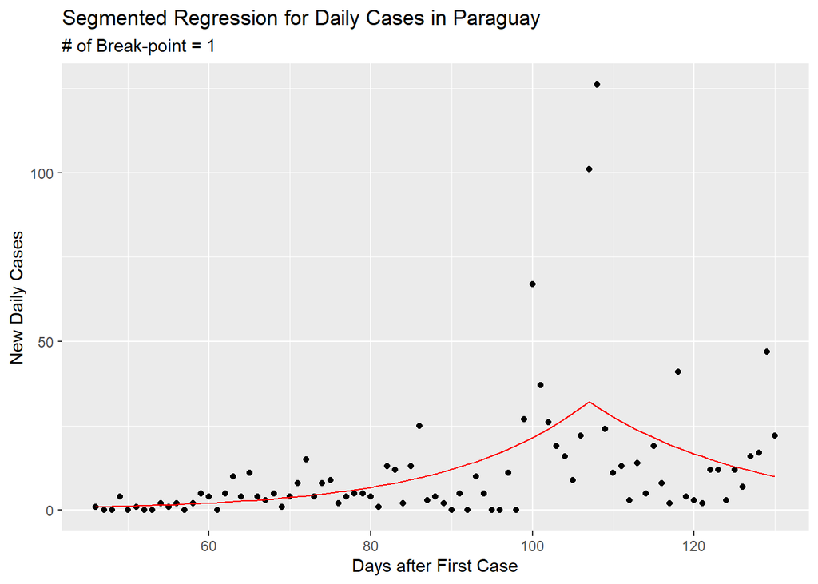

```r
  # Break-point 2개

Paraguay <- Paraguay %>% mutate(seg_fitted = fitted(seg_Poi_P),
                                seg_fitted2 = fitted(seg_Poi_P2))


# plot the fitted model
ggplot(Paraguay) +
  geom_point(aes(Days_after_First_Case, Difference)) +
  geom_line(aes(Days_after_First_Case, seg_fitted), col = 2) +
  labs(title = "Segmented Regression for Daily Cases in Paraguay",
       subtitle = "# of Break-point = 1",
       x = "Days after First Case", y = "New Daily Cases")
```

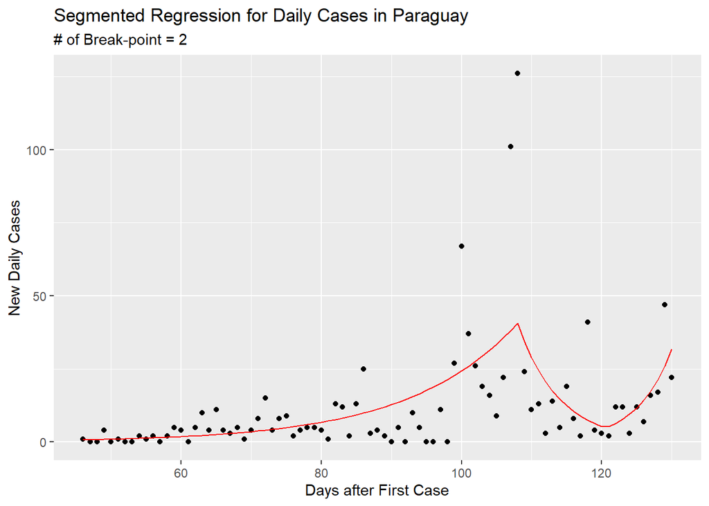

```r
ggplot(Paraguay) +
  geom_point(aes(Days_after_First_Case, Difference)) +
  geom_line(aes(Days_after_First_Case, seg_fitted2), col = 2) +
  labs(title = "Segmented Regression for Daily Cases in Paraguay",
       subtitle = "# of Break-point = 2",
       x = "Days after First Case", y = "New Daily Cases")
```

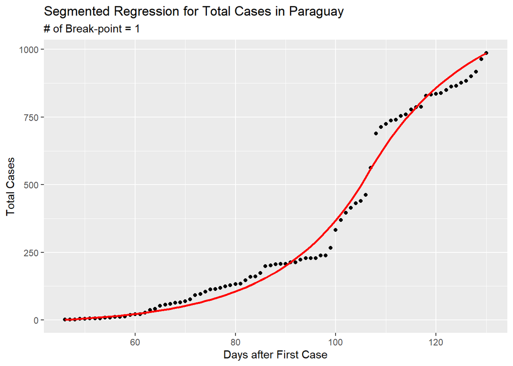

```r
  # Break-point 2개


# Plot the cumulative cases
ggplot(Paraguay) +
  geom_point(aes(Days_after_First_Case, Cases)) +
  geom_line(aes(Days_after_First_Case, cumsum(seg_fitted)), col = 2, size = 1) +
  labs(title = "Segmented Regression for Total Cases in Paraguay",
       subtitle = "# of Break-point = 1",
       x = "Days after First Case", y = "Total Cases")
```

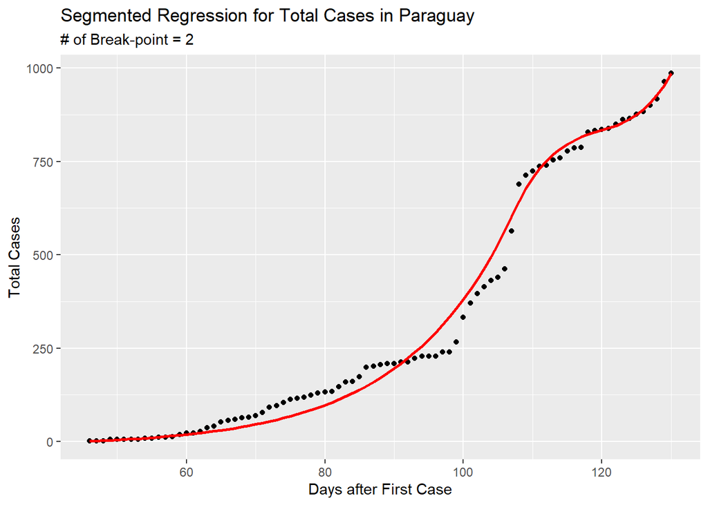

```r
ggplot(Paraguay) +
  geom_point(aes(Days_after_First_Case, Cases)) +
  geom_line(aes(Days_after_First_Case, cumsum(seg_fitted2)), col = 2, size = 1) +
  labs(title = "Segmented Regression for Total Cases in Paraguay",
       subtitle = "# of Break-point = 2",
       x = "Days after First Case", y = "Total Cases")
```

```r
  # changepoints = 2
```

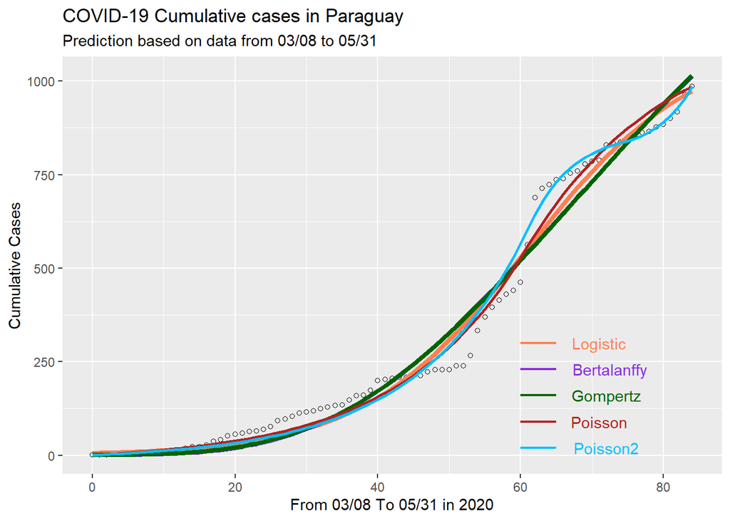

```r
Paraguay_pred <- Paraguay %>%
  mutate(Poi_pred = cumsum(Paraguay$seg_fitted),
         Poi_pred2 = cumsum(Paraguay$seg_fitted2),
         Logistic_pred = predict(fit_log_P, data.frame(X = Paraguay$Days_after_First_Case)),
         Ber_pred = predict(fit_Ber_P, data.frame(X = Paraguay$Days_after_First_Case)),
         Gom_pred = predict(fit_Gom_P, data.frame(X = Paraguay$Days_after_First_Case)))

## Plot
X <- Paraguay$Days_after_First_Case
Y <- Paraguay$Cases

ggplot() +
  geom_point(aes(X-46, Y), shape = 1) +

  # Logistic model
  geom_line(aes(X-46, coef(fit_log_P)[1] / (1 + exp(coef(fit_log_P)[2] + coef(fit_log_P)[3] * X))),
            col = "coral", size = 1.5) +
  geom_line(aes(x = 60:65, y = 300), col = "coral", size = 0.8) +
  geom_text(aes(x = 71, y = 300, label = "Logistic"), color = "coral") +

  # Bertalanffy model
  geom_line(aes(X-46, coef(fit_Ber_P)[1] * ((1 - exp(-coef(fit_Ber_P)[2] * X))^coef(fit_Ber_P)[3])),
             col = "blueviolet", size = 1.5) +
  geom_line(aes(x = 60:65, y = 230), col = "blueviolet", size = 0.8) +
  geom_text(aes(x = 72.5, y = 230, label = "Bertalanffy"), color = "blueviolet") +

  # Gompertz model
  geom_line(aes(X-46, coef(fit_Gom_P)[1] * (exp(-coef(fit_Gom_P)[2] * exp(-coef(fit_Gom_P)[3] * X)))),
             col = "darkgreen", size = 1.5) +
  geom_line(aes(x = 60:65, y = 160), col = "darkgreen", size = 0.8) +
  geom_text(aes(x = 72, y = 160, label = "Gompertz"), color = "darkgreen") +

  # Poisson model
  geom_line(aes(X-46, Paraguay_pred$Poi_pred),
             col = "firebrick", size = 1) +
  geom_line(aes(x = 60:65, y = 90), col = "firebrick", size = 0.8) +
  geom_text(aes(x = 71, y = 90, label = "Poisson"), color = "firebrick") +

  # Poisson model2
  geom_line(aes(X-46, Paraguay_pred$Poi_pred2),
             col = "deepskyblue", size = 1) +
  geom_line(aes(x = 60:65, y = 20), col = "deepskyblue", size = 0.8) +
  geom_text(aes(x = 72, y = 20, label = "Poisson2"), color = "deepskyblue") +

    labs(title = "COVID-19 Cumulative cases in Paraguay",
       subtitle = "Prediction based on data from 03/08 to 05/31",
       x = "From 03/08 To 05/31 in 2020", y = "Cumulative Cases")
```

```r
## Logistic Model MSE
SSE_log_P <- sum((Paraguay_pred$Cases - Paraguay_pred$Logistic_pred)^2)
SST_log_P <- sum((Paraguay_pred$Cases - mean(Paraguay_pred$Cases))^2)
MSE_log_P <- SSE_log_P / length(Paraguay_pred$Cases)


## Bertalanffy Model MSE
SSE_Ber_P <- sum((Paraguay_pred$Cases - Paraguay_pred$Ber_pred)^2)
SST_Ber_P <- sum((Paraguay_pred$Cases - mean(Paraguay_pred$Cases))^2)
MSE_Ber_P <- SSE_Ber_P / length(Paraguay_pred$Cases)


## Gompertz Model MSE
SSE_Gom_P <- sum((Paraguay_pred$Cases - Paraguay_pred$Gom_pred)^2)
SST_Gom_P <- sum((Paraguay_pred$Cases - mean(Paraguay_pred$Cases))^2)
MSE_Gom_P <- SSE_Gom_P / length(Paraguay_pred$Cases)


## Segmented Poisson Model MSE
SSE_Poi_P <- sum((Paraguay_pred$Cases - Paraguay_pred$Poi_pred)^2)
SST_Poi_P <- sum((Paraguay_pred$Cases - mean(Paraguay_pred$Cases))^2)
MSE_Poi_P <- SSE_Poi_P / length(Paraguay_pred$Cases)


## Segmented Poisson Model2 MSE
SSE_Poi_P2 <- sum((Paraguay_pred$Cases - Paraguay_pred$Poi_pred2)^2)
SST_Poi_P2 <- sum((Paraguay_pred$Cases - mean(Paraguay_pred$Cases))^2)
MSE_Poi_P2 <- SSE_Poi_P2 / length(Paraguay_pred$Cases)



cat("(Logistic) MSE : ", MSE_log_P, ", R_Sqaured : ",  1 - SSE_log_P/SST_log_P, "\n")
```

```
## (Logistic) MSE :  1877.188 , R_Sqaured :  0.9822149
```

```r
cat("(Bertalanffy) MSE: ", MSE_Ber_P, ", R_Sqaured : ",  1 - SSE_Ber_P/SST_Ber_P, "\n")
```

```
## (Bertalanffy) MSE:  2670.71 , R_Sqaured :  0.9746967
```

```r
cat("(Gompertz) MSE : ", MSE_Gom_P, ", R_Sqaured : ",  1 - SSE_Gom_P/SST_Gom_P, "\n")
```

```
## (Gompertz) MSE :  2638.974 , R_Sqaured :  0.9749974
```

```r
cat("(Poisson) MSE : ", MSE_Poi_P, ", R_Sqaured : ",  1 - SSE_Poi_P/SST_Poi_P, "\n")
```

```
## (Poisson) MSE :  1286.629 , R_Sqaured :  0.98781
```

```r
cat("(Poisson2) MSE : ", MSE_Poi_P2, ", R_Sqaured : ",  1 - SSE_Poi_P2/SST_Poi_P2)
```

```
## (Poisson2) MSE :  1164.522 , R_Sqaured :  0.9889669
```

파라과이의 일일 신규 확진자 수가 break-point를 1개로 설정하기에는 변동성이 컸기 때문에 2개로 나눈 모형(Poisson2)을 새로 적합시켰다. 헝가리 데이터와 달리 Logistic model이 Bertalanffy, Gompertz model보다 1%p 가량 설명력이 좋으며 두 Poisson model이 Logistic model보다 약 0.5%p 정도 설명력이 좋음을 알 수 있다. 그래프나, MSE, $R^2$를 비교했을 때 (Poisson2) 모델이 (Poisson)에 비해 설명력이 좋은 것으로 나타나지만 0.1%p 가량을 더 설명하고 덜 설명하고의 차이기 때문에 만약 과적합을 의식한다면 (Poisson) 모델을 그대로 사용해도 좋을 것이다.

### 4. Brazil에서 적합했던 Logistic, Bertalanffy, Gompertz model의 예측이 정확하지 않음을 보았다. 이는 브라질의 일일 확진자 수가 줄어든다고 예상했던 것과 달리 날이 갈수록 증가한 까닭이다. Segmented Poisson model로 예측해보고 더 나은 모델을 찾아보자.

#### (4-1) Segmented Poisson model for predicting COVID-19 cases in Brazil

```r
set.seed(1234)
fit_Poi_B <- glm(Difference ~ Days_after_First_Case, family = poisson, Brazil_train)
seg_Poi_B <- segmented(fit_Poi_B, seg.Z = ~ Days_after_First_Case, npsi = 1)
seg_Poi_B2 <- segmented(fit_Poi_B, seg.Z = ~ Days_after_First_Case, npsi = 2)
summary(seg_Poi_B); summary(seg_Poi_B2)
```

```
##
##  ***Regression Model with Segmented Relationship(s)***
##
## Call:
## segmented.glm(obj = fit_Poi_B, seg.Z = ~Days_after_First_Case,
##     npsi = 1)
##
## Estimated Break-Point(s):
##                             Est. St.Err
## psi1.Days_after_First_Case   60  0.151
##
## Meaningful coefficients of the linear terms:
##                            Estimate Std. Error z value Pr(>|z|)
## (Intercept)              -12.800421   0.482415  -26.53   <2e-16 ***
## Days_after_First_Case      0.313063   0.008391   37.31   <2e-16 ***
## U1.Days_after_First_Case  -0.241052   0.008421  -28.62       NA
## ---
## Signif. codes:  0 '***' 0.001 '**' 0.01 '*' 0.05 '.' 0.1 ' ' 1
## (Dispersion parameter for poisson family taken to be 1)
##
## Null     deviance: 57054.4  on 53  degrees of freedom
## Residual deviance:  3936.8  on 50  degrees of freedom
## AIC: 4279
##
## Convergence attained in 0 iter. (rel. change 3.2063e-07)
```

```
##
##  ***Regression Model with Segmented Relationship(s)***
##
## Call:
## segmented.glm(obj = fit_Poi_B, seg.Z = ~Days_after_First_Case,
##     npsi = 2)
##
## Estimated Break-Point(s):
##                              Est. St.Err
## psi1.Days_after_First_Case 57.23  0.301
## psi2.Days_after_First_Case 71.00  0.345
##
## Meaningful coefficients of the linear terms:
##                            Estimate Std. Error z value Pr(>|z|)
## (Intercept)              -13.778376   0.741524  -18.58   <2e-16 ***
## Days_after_First_Case      0.332406   0.013592   24.45   <2e-16 ***
## U1.Days_after_First_Case  -0.209065   0.013943  -14.99       NA
## U2.Days_after_First_Case  -0.066050   0.003328  -19.85       NA
## ---
## Signif. codes:  0 '***' 0.001 '**' 0.01 '*' 0.05 '.' 0.1 ' ' 1
## (Dispersion parameter for poisson family taken to be 1)
##
## Null     deviance: 57054.4  on 53  degrees of freedom
## Residual deviance:  3581.4  on 48  degrees of freedom
## AIC: 3927.7
##
## Convergence attained in 5 iter. (rel. change 5.3256e-06)
```

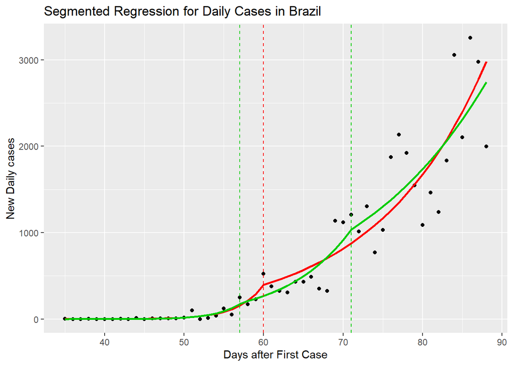

```r
Brazil_train <- Brazil_train %>%
  mutate(seg_fitted = fitted(seg_Poi_B),
         seg_fitted2 = fitted(seg_Poi_B2))

# plot the fitted model
ggplot(Brazil_train) +
  geom_point(aes(Days_after_First_Case, Difference)) +
  geom_line(aes(Days_after_First_Case, seg_fitted), col = 2, size = 1) +
  geom_line(aes(Days_after_First_Case, seg_fitted2), col = 3, size = 1) +
  labs(title = "Segmented Regression for Daily Cases in Brazil",
       x = "Days after First Case", y = "New Daily cases") +
  geom_vline(aes(xintercept = 60), linetype = "dashed", col = 2, size = 0.5) +
  geom_vline(aes(xintercept = 57), linetype = "dashed", col = 3, size = 0.5) +
  geom_vline(aes(xintercept = 71), linetype = "dashed", col = 3, size = 0.5)
```

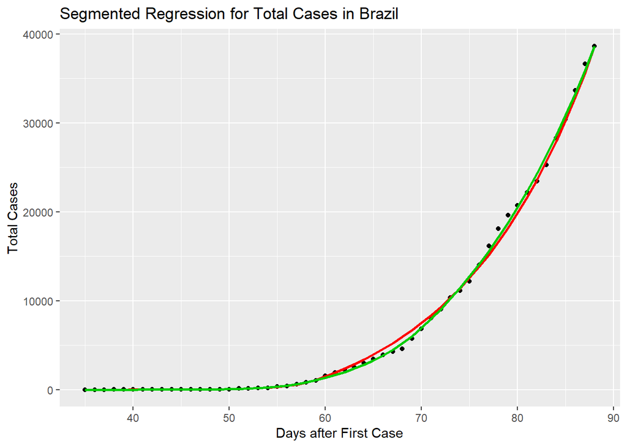

```r
# Plot the cumulative cases
ggplot(Brazil_train) +
  geom_point(aes(Days_after_First_Case, Cases)) +
  geom_line(aes(Days_after_First_Case, cumsum(seg_fitted)), col = 2, size = 1) +
  geom_line(aes(Days_after_First_Case, cumsum(seg_fitted2)), col = 3, size = 1) +
  labs(title = "Segmented Regression for Total Cases in Brazil",
       x = "Days after First Case", y = "Total Cases")
```

2020년 2월 26일부터 4월 19일까지의 Brazil training set을 바탕으로 Segmented Poisson regression을 돌려본 결과 npsi = 1 일 때, x = 60 (default)에서 changepoint가 형성되며 npsi = 2일 때는 x = 57, x = 71에서 changepoint가 형성되었다.

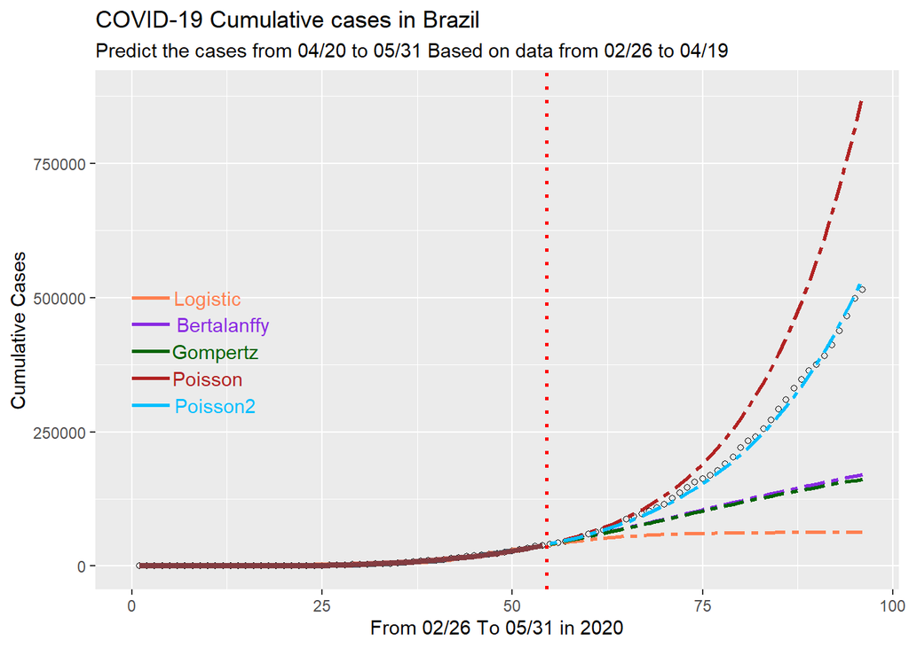

```r
X <- Brazil_train$Days_after_First_Case
Y <- Brazil_train$Cases
X_pred <- Brazil_valid$Days_after_First_Case
Y_pred <- Brazil_valid$Cases

Brazil_pred <- Brazil_valid %>%
  mutate(Logistic_pred = predict(fit_log_B, data.frame(X = X_pred)),
         Ber_pred = predict(fit_Ber_B, data.frame(X = X_pred)),
         Gom_pred = predict(fit_Gom_B, data.frame(X = X_pred)),
         Poi_pred = cumsum(predict(seg_Poi_B, data.frame(Days_after_First_Case = X_pred), type = "response")) + cumsum(Brazil_train$seg_fitted)[[54]],
         Poi_pred2 = cumsum(predict(seg_Poi_B2, data.frame(Days_after_First_Case = X_pred), type = "response")) + cumsum(Brazil_train$seg_fitted2)[[54]])
  # Poi_pred, Poi_pred2 부분이 복잡하긴 한데, train에서 cumsum한 것까지 더해줘야 함.


ggplot() +
  geom_point(aes(X-34, Y), shape = 1) +
  geom_line(aes(X-34, coef(fit_log_B)[1] / (1 + exp(coef(fit_log_B)[2] + coef(fit_log_B)[3] * X))),
            color = "coral", size = 1.5, alpha = 0.7) +
  geom_line(aes(X-34, coef(fit_Ber_B)[1] * ((1 - exp(-coef(fit_Ber_B)[2] * X))^coef(fit_Ber_B)[3])),
            color = "blueviolet", size = 1.5, alpha = 0.7) +
  geom_line(aes(X-34, coef(fit_Gom_B)[1] * (exp(-coef(fit_Gom_B)[2] * exp(-coef(fit_Gom_B)[3] * X)))),
            color = "darkgreen", size = 1.5, alpha = 0.5) +
  geom_line(aes(X-34, cumsum(Brazil_train$seg_fitted)), color = "firebrick", size = 1.5, alpha = 0.5) +
  labs(title = "COVID-19 Cumulative cases in Brazil",
       subtitle = "Predict the cases from 04/20 to 05/31 Based on data from 02/26 to 04/19",
       x = "From 02/26 To 05/31 in 2020", y = "Cumulative Cases") +

  # 4월 20일부터 5월 31일까지 예측
  geom_point(aes(X_pred-34, Y_pred), shape = 1) +
  geom_vline(xintercept = 88.5-34, col = "red", lwd = 1, linetype = 3) +

  # Logistic model
  geom_line(aes(X_pred-34, Brazil_pred$Logistic_pred),
             col = "coral", size = 1, linetype = 6) +
  geom_line(aes(x = 0:5, y = 500000), col = "coral", size = 1) +
  geom_text(aes(x = 10, y = 500000, label = "Logistic"), color = "coral") +

  # Bertalanffy model
  geom_line(aes(X_pred-34, Brazil_pred$Ber_pred),
             col = "blueviolet", size = 1, linetype = 6) +
  geom_line(aes(x = 0:5, y = 450000), col = "blueviolet", size = 1) +
  geom_text(aes(x = 12, y = 450000, label = "Bertalanffy"), color = "blueviolet") +

  # Gompertz model
  geom_line(aes(X_pred-34, Brazil_pred$Gom_pred),
             col = "darkgreen", size = 1, linetype = 6) +
  geom_line(aes(x = 0:5, y = 400000), col = "darkgreen", size = 1) +
  geom_text(aes(x = 11, y = 400000, label = "Gompertz"), color = "darkgreen") +

  # Poisson model
  geom_line(aes(X_pred-34, Brazil_pred$Poi_pred),
             col = "firebrick", size = 1, linetype = 6) +
  geom_line(aes(x = 0:5, y = 350000), col = "firebrick", size = 1) +
  geom_text(aes(x = 10, y = 350000, label = "Poisson"), color = "firebrick") +

  # Poisson2 model
  geom_line(aes(X_pred-34, Brazil_pred$Poi_pred2),
             col = "deepskyblue", size = 1, linetype = 6) +
  geom_line(aes(x = 0:5, y = 300000), col = "deepskyblue", size = 1) +
  geom_text(aes(x = 11, y = 300000, label = "Poisson2"), color = "deepskyblue")
```

```r
## Logistic Model MSE
SSE_log <- sum((Brazil_pred$Cases - Brazil_pred$Logistic_pred)^2)
SST_log <- sum((Brazil_pred$Cases - mean(Brazil_train$Cases))^2)
MSE_log <- SSE_log / length(Brazil_pred$Cases)


## Bertalanffy Model MSE
SSE_Ber <- sum((Brazil_pred$Cases - Brazil_pred$Ber_pred)^2)
SST_Ber <- sum((Brazil_pred$Cases - mean(Brazil_train$Cases))^2)
MSE_Ber <- SSE_Ber / length(Brazil_pred$Cases)


## Gompertz Model MSE
SSE_Gom <- sum((Brazil_pred$Cases - Brazil_pred$Gom_pred)^2)
SST_Gom <- sum((Brazil_pred$Cases - mean(Brazil_train$Cases))^2)
MSE_Gom <- SSE_Gom / length(Brazil_pred$Cases)


## Segmented Poisson Model MSE
SSE_Poi <- sum((Brazil_pred$Cases - Brazil_pred$Poi_pred)^2)
SST_Poi <- sum((Brazil_pred$Cases - mean(Brazil_train$Cases))^2)
MSE_Poi <- SSE_Poi / length(Brazil_pred$Cases)


## Segmented Poisson Model2 MSE
SSE_Poi2 <- sum((Brazil_pred$Cases - Brazil_pred$Poi_pred2)^2)
SST_Poi2 <- sum((Brazil_pred$Cases - mean(Brazil_train$Cases))^2)
MSE_Poi2 <- SSE_Poi2 / length(Brazil_pred$Cases)



cat("(Logistic) MSE : ", MSE_log, ", R_Sqaured : ",  1 - SSE_log/SST_log, "\n")
```

```
## (Logistic) MSE :  39437115377 , R_Sqaured :  0.3204375
```

```r
cat("(Bertalanffy) MSE: ", MSE_Ber, ", R_Sqaured : ",  1 - SSE_Ber/SST_Ber, "\n")
```

```
## (Bertalanffy) MSE:  20014585604 , R_Sqaured :  0.6551177
```

```r
cat("(Gompertz) MSE : ", MSE_Gom, ", R_Sqaured : ",  1 - SSE_Gom/SST_Gom, "\n")
```

```
## (Gompertz) MSE :  21110099077 , R_Sqaured :  0.6362403
```

```r
cat("(Poisson) MSE : ", MSE_Poi, ", R_Sqaured : ",  1 - SSE_Poi/SST_Poi, "\n")
```

```
## (Poisson) MSE :  15914399731 , R_Sqaured :  0.7257703
```

```r
cat("(Poisson2) MSE : ", MSE_Poi2, ", R_Sqaured : ",  1 - SSE_Poi2/SST_Poi2)
```

```
## (Poisson2) MSE :  68849549 , R_Sqaured :  0.9988136
```

#### (4-2) Spline model for predicting COVID-19 cases in Brazil

```r
## Spline Interpolation Regression
require(splines)
X <- Brazil_train$Days_after_First_Case
Y <- Brazil_train$Cases

X_lims <- range(X)

#Generating Test Data
X.grid <- seq(from = X_lims[1], to = X_lims[2])

#3 cutpoints at X 69, 83
fit<-lm(Y ~ bs(X, knots = c(69, 78)))
summary(fit)
```

```
##
## Call:
## lm(formula = Y ~ bs(X, knots = c(69, 78)))
##
## Residuals:
##     Min      1Q  Median      3Q     Max
## -863.50 -157.79    9.29  120.96  988.32
##
## Coefficients:
##                           Estimate Std. Error t value Pr(>|t|)
## (Intercept)                 -347.1      216.3  -1.605 0.115139
## bs(X, knots = c(69, 78))1   2071.4      533.9   3.880 0.000318 ***
## bs(X, knots = c(69, 78))2  -4611.1      347.9 -13.255  < 2e-16 ***
## bs(X, knots = c(69, 78))3  16849.8      385.8  43.670  < 2e-16 ***
## bs(X, knots = c(69, 78))4  29026.2      397.2  73.073  < 2e-16 ***
## bs(X, knots = c(69, 78))5  39398.6      379.9 103.702  < 2e-16 ***
## ---
## Signif. codes:  0 '***' 0.001 '**' 0.01 '*' 0.05 '.' 0.1 ' ' 1
##
## Residual standard error: 378.8 on 48 degrees of freedom
## Multiple R-squared:  0.9989, Adjusted R-squared:  0.9988
## F-statistic:  8887 on 5 and 48 DF,  p-value: < 2.2e-16
```

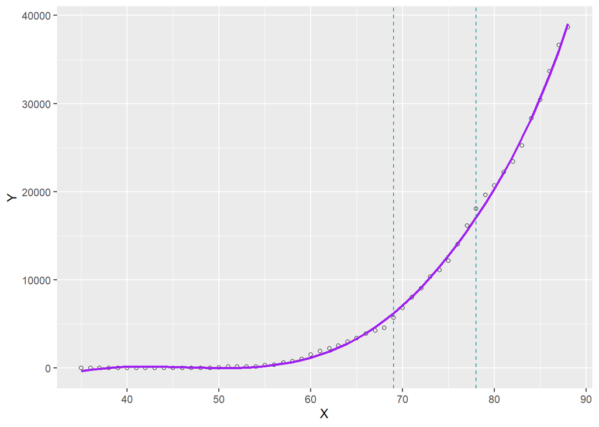

```r
#Plotting the Regression Line to the scatterplot

ggplot() +
  geom_point(aes(X, Y), shape = 1) +
  geom_line(aes(X, predict(fit, newdata = list(X = X.grid))), col = "purple", size = 1) +
  geom_vline(xintercept = 69, col = "darkcyan", linetype = 2, alpha = 0.8) +
  geom_vline(xintercept = 78, col = "darkcyan", linetype = 2, alpha = 0.8)
```

```r
## 4월 20일부터 5월 31일까지의 누적 확진자 수 예측
predict(fit, newdata = list(X = Brazil_valid$Days_after_First_Case))
```

```
##         1         2         3         4         5         6         7
##  42284.84  45772.36  49530.36  53575.19  57923.17  62590.65  67593.94
##         8         9        10        11        12        13        14
##  72949.38  78673.31  84782.06  91291.95  98219.33 105580.52 113391.85
##        15        16        17        18        19        20        21
## 121669.66 130430.28 139690.04 149465.27 159772.31 170627.49 182047.14
##        22        23        24        25        26        27        28
## 194047.59 206645.17 219856.22 233697.06 248184.04 263333.48 279161.72
##        29        30        31        32        33        34        35
## 295685.08 312919.90 330882.51 349589.24 369056.43 389300.41 410337.50
##        36        37        38        39        40        41        42
## 432184.05 454856.38 478370.82 502743.72 527991.39 554130.18 581176.41
```

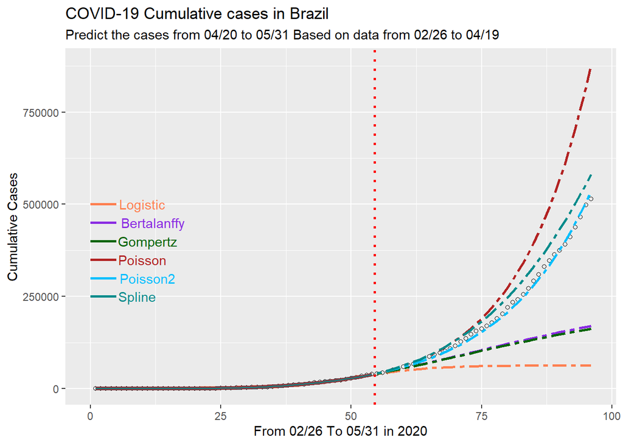

```r
## Logistic vs Bertalanffy vs Gompertz vs Poisson vs Poisson2 vs Spline
ggplot() +

  # 2월 26일부터 4월 19일까지 train
  geom_point(aes(X-34, Y), shape = 1) +
  geom_line(aes(X-34, coef(fit_log_B)[1] / (1 + exp(coef(fit_log_B)[2] + coef(fit_log_B)[3] * X))),
            color = "coral", size = 1.5, alpha = 0.7) +
  geom_line(aes(X-34, coef(fit_Ber_B)[1] * ((1 - exp(-coef(fit_Ber_B)[2] * X))^coef(fit_Ber_B)[3])),
            color = "blueviolet", size = 1.5, alpha = 0.7) +
  geom_line(aes(X-34, coef(fit_Gom_B)[1] * (exp(-coef(fit_Gom_B)[2] * exp(-coef(fit_Gom_B)[3] * X)))),
            color = "darkgreen", size = 1.5, alpha = 0.5) +
  geom_line(aes(X-34, cumsum(Brazil_train$seg_fitted)), color = "firebrick", size = 1.5, alpha = 0.5) +
  geom_line(aes(X-34, predict(fit, newdata = list(X = X.grid))), col = "darkcyan") +


  # 4월 20일부터 5월 31일까지 prediction
  geom_point(aes(X_pred-34, Y_pred), shape = 1) +
  geom_vline(xintercept = 88.5-34, col = "red", lwd = 1, linetype = 3) +

  # Logistic model
  geom_line(aes(X_pred-34, Brazil_pred$Logistic_pred),
             col = "coral", size = 1, linetype = 6) +
  geom_line(aes(x = 0:5, y = 500000), col = "coral", size = 1) +
  geom_text(aes(x = 10, y = 500000, label = "Logistic"), color = "coral") +

  # Bertalanffy model
  geom_line(aes(X_pred-34, Brazil_pred$Ber_pred),
             col = "blueviolet", size = 1, linetype = 6) +
  geom_line(aes(x = 0:5, y = 450000), col = "blueviolet", size = 1) +
  geom_text(aes(x = 12, y = 450000, label = "Bertalanffy"), color = "blueviolet") +

  # Gompertz model
  geom_line(aes(X_pred-34, Brazil_pred$Gom_pred),
             col = "darkgreen", size = 1, linetype = 6) +
  geom_line(aes(x = 0:5, y = 400000), col = "darkgreen", size = 1) +
  geom_text(aes(x = 11, y = 400000, label = "Gompertz"), color = "darkgreen") +

  # Poisson model
  geom_line(aes(X_pred-34, Brazil_pred$Poi_pred),
             col = "firebrick", size = 1, linetype = 6) +
  geom_line(aes(x = 0:5, y = 350000), col = "firebrick", size = 1) +
  geom_text(aes(x = 10, y = 350000, label = "Poisson"), color = "firebrick") +

  # Poisson2 model
  geom_line(aes(X_pred-34, Brazil_pred$Poi_pred2),
             col = "deepskyblue", size = 1, linetype = 6) +
  geom_line(aes(x = 0:5, y = 300000), col = "deepskyblue", size = 1) +
  geom_text(aes(x = 11, y = 300000, label = "Poisson2"), color = "deepskyblue") +

  # Spline model
  geom_line(aes(X_pred-34, predict(fit, newdata = list(X = Brazil_valid$Days_after_First_Case))),
             col = "darkcyan", size = 1, linetype = 6) +
  geom_line(aes(x = 0:5, y = 250000), col = "darkcyan", size = 1) +
  geom_text(aes(x = 9, y = 250000, label = "Spline"), color = "darkcyan") +


  labs(title = "COVID-19 Cumulative cases in Brazil",
       subtitle = "Predict the cases from 04/20 to 05/31 Based on data from 02/26 to 04/19",
       x = "From 02/26 To 05/31 in 2020", y = "Cumulative Cases")
```

```r
## MSPE 예측

# Spline Regression model MSE
SSE_Spl <- sum((Brazil_pred$Cases - predict(fit, newdata = list(X = Brazil_valid$Days_after_First_Case)))^2)
SST_Spl <- sum((Brazil_pred$Cases - mean(Brazil_train$Cases))^2)
MSE_Spl <- SSE_Spl / length(Brazil_pred$Cases)

cat("(Logistic) MSE : ", MSE_log, ", R_Sqaured : ",  1 - SSE_log/SST_log, "\n")
```

```
## (Logistic) MSE :  39437115377 , R_Sqaured :  0.3204375
```

```r
cat("(Bertalanffy) MSE: ", MSE_Ber, ", R_Sqaured : ",  1 - SSE_Ber/SST_Ber, "\n")
```

```
## (Bertalanffy) MSE:  20014585604 , R_Sqaured :  0.6551177
```

```r
cat("(Gompertz) MSE : ", MSE_Gom, ", R_Sqaured : ",  1 - SSE_Gom/SST_Gom, "\n")
```

```
## (Gompertz) MSE :  21110099077 , R_Sqaured :  0.6362403
```

```r
cat("(Poisson) MSE : ", MSE_Poi, ", R_Sqaured : ",  1 - SSE_Poi/SST_Poi, "\n")
```

```
## (Poisson) MSE :  15914399731 , R_Sqaured :  0.7257703
```

```r
cat("(Poisson2) MSE : ", MSE_Poi2, ", R_Sqaured : ",  1 - SSE_Poi2/SST_Poi2, "\n")
```

```
## (Poisson2) MSE :  68849549 , R_Sqaured :  0.9988136
```

```r
cat("(Spline) MSE : ", MSE_Spl, ", R_Sqaured : ",  1 - SSE_Spl/SST_Spl)
```

```
## (Spline) MSE :  1130674074 , R_Sqaured :  0.9805167
```

6가지 모델을 적합시킨 결과 MSPE 기준으로 Poisson2 > Spline > Poisson > Bertalanffy > Gompertz > Logistic model 순으로 설명력이 높았다. Poisson2 model과 Spline model 모두 공통적으로 segmentation 개념을 사용하여 break-point 또는 knot를 사전에 결정하여 적합시킨다는 특징을 갖는다. 연구자의 주관성이 개입될 수 있다는 점이 한계로 작용할 수 있지만 브라질 데이터의 경우 Logistic, Bertalanffy, Gompertz 3개의 모델의 변곡점이 너무 일찍 형성되어 $R^2$ 값이 상당히 낮았기 때문에 이를 보완하기 위해 Segmented Poisson이나 Spline model에서처럼 training data에 추가적인 정보를 집어 넣었다. 그 결과, MSPE 값이 현저히 떨어졌으며(break-point가 하나인 Poisson에 비해 두 개인 Poisson2의 정확도가 훨씬 증가하였으며 마찬가지로 Spline model 역시 Poisson2 모델에 버금가는 정확도를 보여준다.) 설명력이 좋아질 수 있었다. 하지만 여전히 과적합의 문제는 조심해야 할 것이다.